# Loneliness, preview of data

## Sample Description

|  | Age | PHQ9_PRE | UCLA_PRE | PHQ9_POST | UCLA_POST |
| --- | --- | --- | --- | --- | --- |
|  | Min. :21.00 | Min. : 0.000 | Min. :3.000 | Min. : 0.000 | Min. :3.000 |
|  | 1st Qu.:30.00 | 1st Qu.: 3.000 | 1st Qu.:4.000 | 1st Qu.: 3.000 | 1st Qu.:4.000 |
|  | Median :37.00 | Median : 8.000 | Median :6.000 | Median : 5.000 | Median :6.000 |
|  | Mean :40.08 | Mean : 8.246 | Mean :5.852 | Mean : 6.459 | Mean :5.492 |
|  | 3rd Qu.:51.00 | 3rd Qu.:12.000 | 3rd Qu.:7.000 | 3rd Qu.:10.000 | 3rd Qu.:7.000 |
|  | Max. :66.00 | Max. :24.000 | Max. :9.000 | Max. :22.000 | Max. :9.000 |

Total sample: N = 61

## Age Distribution

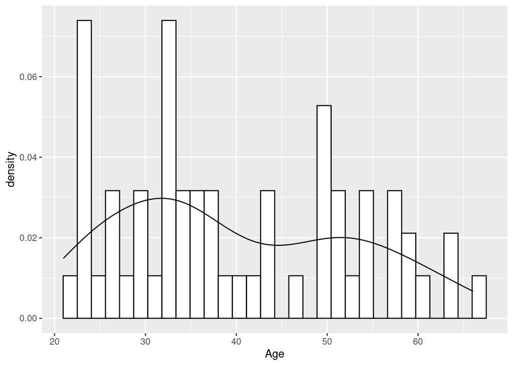

## Correlation between Depression score and loneliness scores

Total sample: N = 61

A significant medium correlation r = 0.4 is present between depression and loneliness at baseline

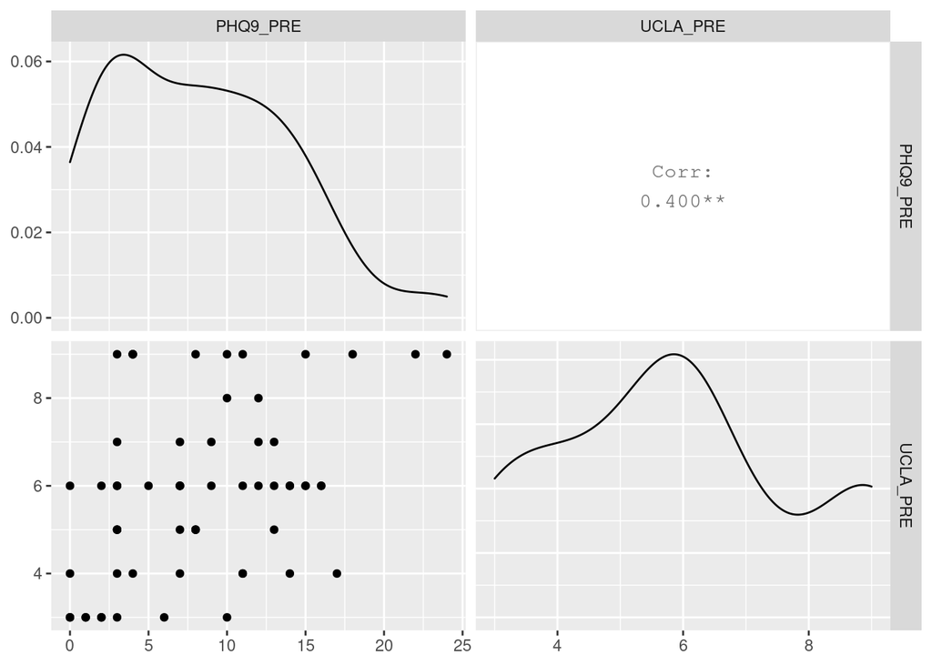

## Improvements for the clinical subset

Clinical subset = all partipants who had a PHQ9 score greater or equal to 10

This clinical subset was n = 25.

The number is smaller than 30 and so I will apply a non-parametric approach to assess the significance of the effect of the exposure to the TFH programme on depression and on loneliness.

The plot shows the results attained via bootstrap. Cohens’ d was estimated as 1.28 and .40 suggesting respectively a large effect of the exposure to the TFH programme on the depression scores and a medium effect on the loneliness score.

While the difference in depression scores is evident (even with this small subset sample), the improvement that is noted on the Loneliness score at the end of the programme is only marginally significant and does not carry the same confidence as that showed on the change in PHQ9 scores. More data is required to support these prelimirary observations on the change in PHQ9 and UCLA score before and after the TFH programme.

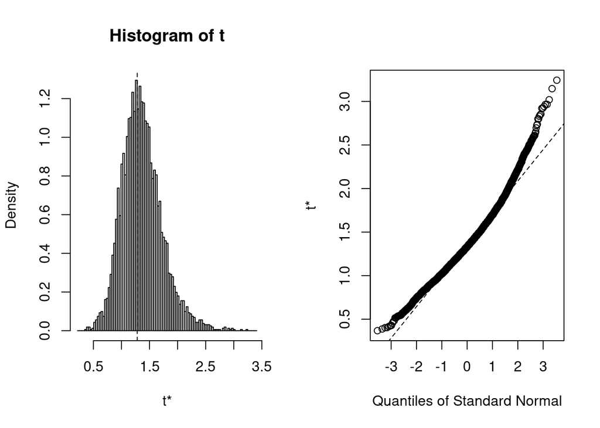

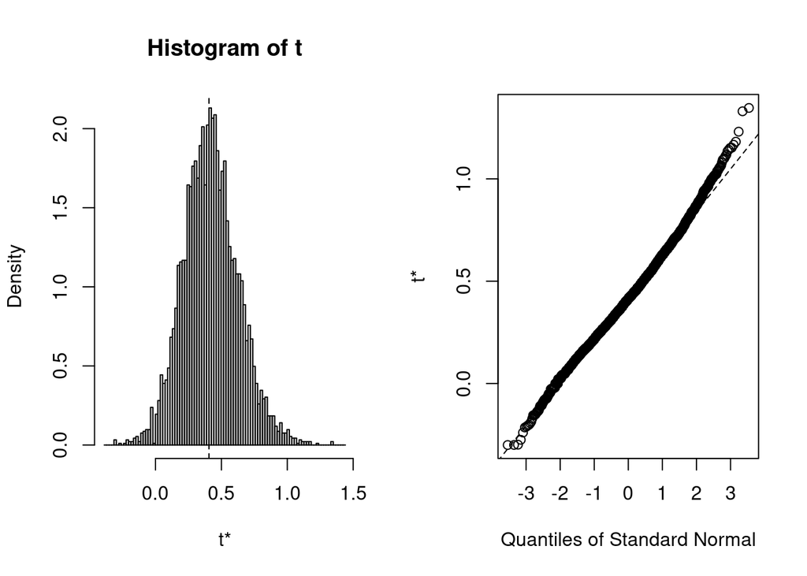

Cohen’s d effect size (t0) and 95% bca CI

|  | t0 | lowerCI | upperCI | N. Cases | 1-beta |
| --- | --- | --- | --- | --- | --- |
| Depression | 1.281 | 0.654 | 2.02 | 25 | 0.996 |
| Loneliness | 0.406 | 0.022 | 0.84 | 25 | 0.552 |

Boxplot show the change in scores before and after therapy.

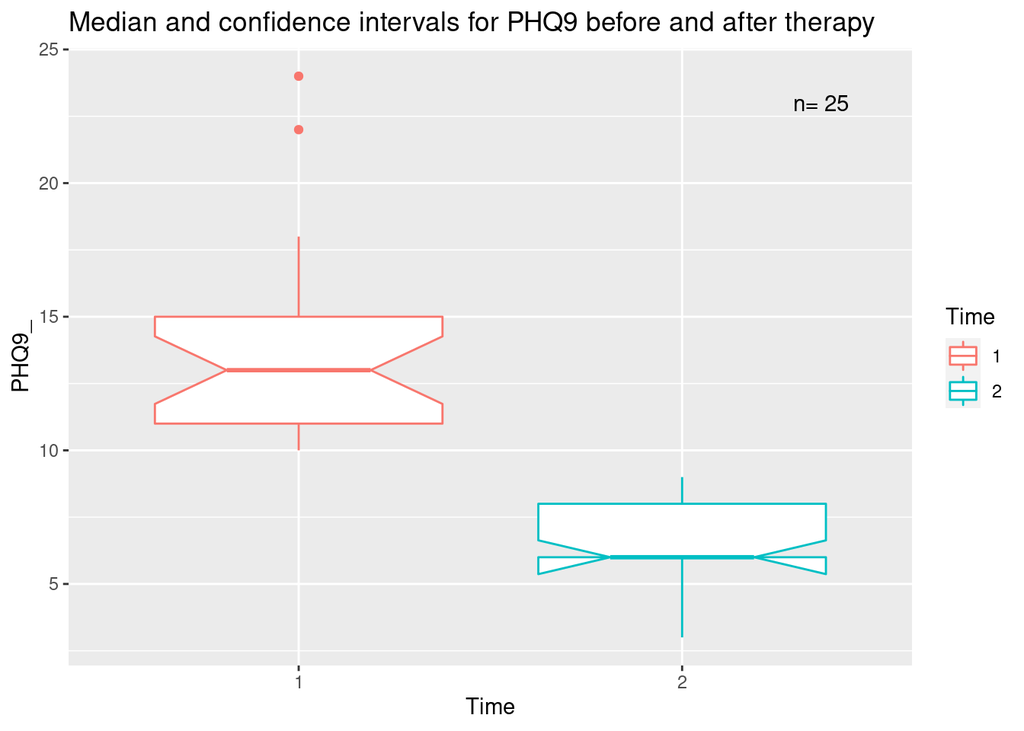

[figure not shown]